# ESM 201 HW 2

Janelle Christensen

3/6/2020

### 1. Patterns in yield over time

##### a. Finalized plot of yield over time

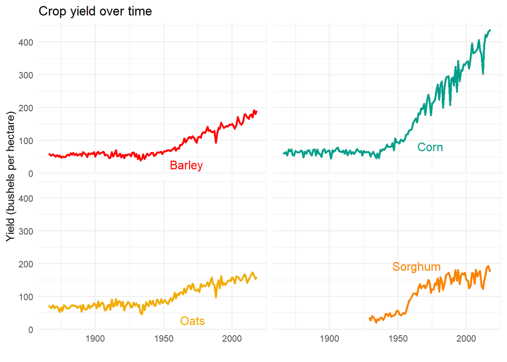

##### b. Crop trends

In this case, it looks like Barley, Corn and Oats are all following the linear lower plateau curve. Sorghum is a little harder to determine because of there isn’t as much data, but it looks more like a linear upper plateau or a linear piecewise with a decreasing rate.

##### c. Extra

|  | *Dependent variable:* |
| --- | --- |
|  | Yield |
| Hectares Planted | -37.966*** |
|  | (5.015) |
| Hectares Harvested | 39.694*** |
|  | (5.813) |
| Constant | 323.761*** |
|  | (74.985) |
| Observations | 93 |
| R<sup>2</sup> | 0.389 |
| Adjusted R<sup>2</sup> | 0.376 |
| Residual Std. Error | 94.406 (df = 90) |
| F Statistic | 28.659*** (df = 2; 90) |
| *Note:* | p<0.1; p<0.05; p<0.01 |

### 2. Fertilizer Use

##### a. Finalized plot of fertilizer use

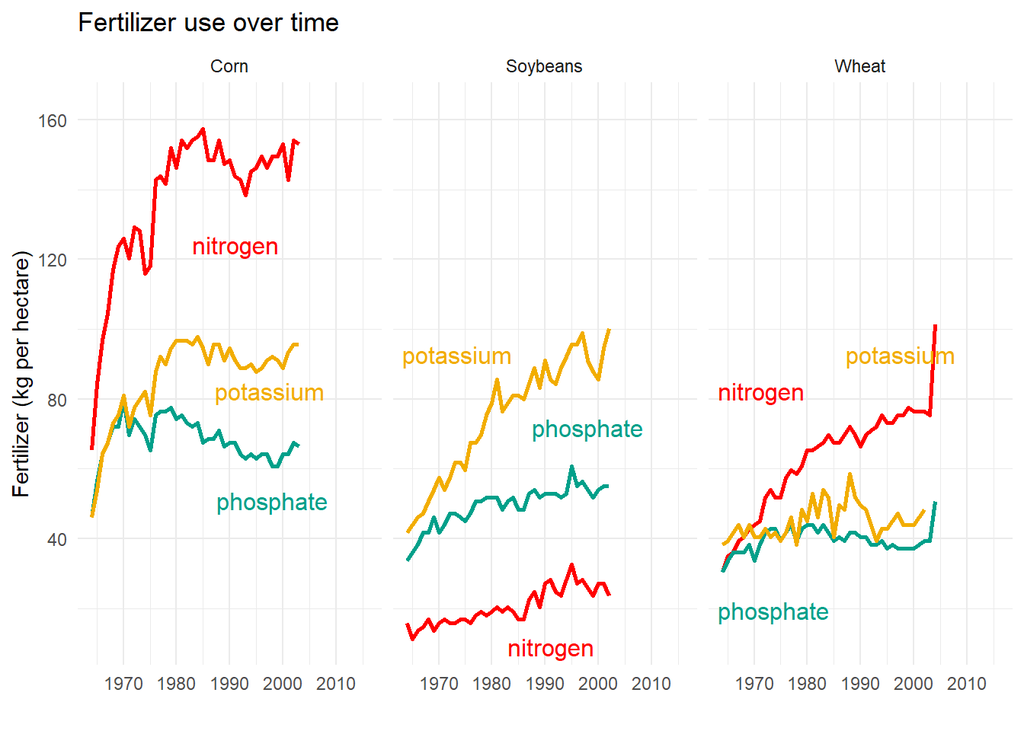

##### b. Limiting nutrients

All three plants use different levels of these nutrients. In terms of application, it looks like both wheat and corn have the most nitrogen applied, whereas soybeans have the most potassium applied.

Because the limiting nutrient will be the one that has the highest level of application to the crop to encourage growth, nitrogen is limiting for wheat and corn and potassium is limiting for soybeans.

### 3. Case Study

##### a. Finalized plot of fertilizer vs. yield

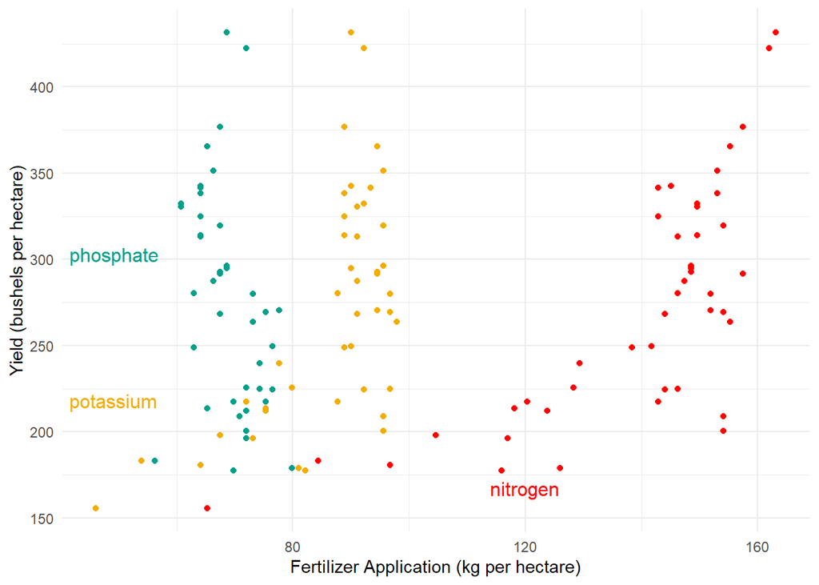